# Forward Error in Linear Systems

- Show All Code
- Hide All Code

Author

Nathan Lunceford

## **Overview**

The **forward error** is a critical concept in numerical linear algebra, measuring the difference between the approximate solution $\mathbf{x_a}$ and the true solution $\mathbf{x}$ of a linear system $A\mathbf{x} = \mathbf{b}$. It quantifies how far the computed solution is from the exact solution, providing insight into the accuracy of numerical methods.

The forward error is defined as:

$$\text{FE} = \|\mathbf{x} - \mathbf{x_a}\|_\infty$$

where:

- $\mathbf{x}$: The **true solution** of the system $A\mathbf{x} = \mathbf{b}$,
- $\mathbf{x_a}$: The **approximate solution**,
- $\|\cdot\|_\infty$: The **infinity norm**, measuring the maximum absolute entry of the vector.

## **What Forward Error Represents**

1. **Solution Accuracy**:
   - The forward error reflects the maximum difference between the components of the true solution and the approximate solution.
2. **Component-wise Deviation**:
   - It indicates the largest deviation in any component of the solution vector.
3. **Exact Solution**:
   - If $\mathbf{x_a}$ is the exact solution, then:

     $$\text{FE} = 0$$

## **Why Forward Error Matters**

- **Assessing Solution Quality**:
  - The forward error directly measures the accuracy of the approximate solution, helping determine how close it is to the true solution.
- **Error Propagation**:
  - Understanding the forward error aids in analyzing how errors in computations propagate through the solution process.
- **Numerical Stability**:
  - A small forward error indicates that the numerical method is producing reliable results.

## **Example**

To enhance the visualization, we’ll adjust the approximate solution $\mathbf{x_a}$ so that the differences in both components are whole numbers but **not equal**, providing a clearer depiction of forward error in multiple dimensions.

Consider the system:

$$A = \begin{bmatrix} 1 & 1 \\ 3 & -4 \end{bmatrix}, \quad
\mathbf{b} = \begin{bmatrix} 3 \\ 2 \end{bmatrix}, \quad
\mathbf{x} = \begin{bmatrix} 2 \\ 1 \end{bmatrix}, \quad
\mathbf{x_a} = \begin{bmatrix} 1 \\ -1 \end{bmatrix}$$

### **Step 1: Verify the True Solution**

Check that $\mathbf{x}$ satisfies $A\mathbf{x} = \mathbf{b}$:

$$A\mathbf{x} = \begin{bmatrix} 1 \times 2 + 1 \times 1 \\ 3 \times 2 + (-4) \times 1 \end{bmatrix} = \begin{bmatrix} 3 \\ 2 \end{bmatrix} = \mathbf{b}$$

### **Step 2: Compute the Forward Error**

Compute the difference between $\mathbf{x}$ and $\mathbf{x_a}$:

$$\mathbf{e} = \mathbf{x} - \mathbf{x_a} = \begin{bmatrix} 2 - 1 \\ 1 - (-1) \end{bmatrix} = \begin{bmatrix} 1 \\ 2 \end{bmatrix}$$

The forward error is the infinity norm of $\mathbf{e}$:

$$\text{FE} = \|\mathbf{e}\|_\infty = \max(|1|, |2|) = 2$$

### **Step 3: Interpretation**

- The maximum deviation between the true and approximate solutions is $2$, occurring in the second component.
- The approximate solution $\mathbf{x_a}$ differs from $\mathbf{x}$ by $1$ in the $x$-component and $2$ in the $y$-component.

## **Visualization of Forward Error**

To illustrate the forward error, we will visualize the true solution $\mathbf{x}$ and the approximate solution $\mathbf{x_a}$, along with the error vector $\mathbf{e} = \mathbf{x} - \mathbf{x_a}$. By plotting these vectors, we can see how the approximate solution deviates from the true solution in both components.

- **Black Vector** ($\mathbf{x}$): The true solution vector.
- **Gray Vector** ($\mathbf{x_a}$): The approximate solution vector.
- **Orange Vector** ($\mathbf{e} = \mathbf{x} - \mathbf{x_a}$): The error vector.
- **Error Components**: Projections of $\mathbf{e}$ onto the $x$ and $y$ axes.

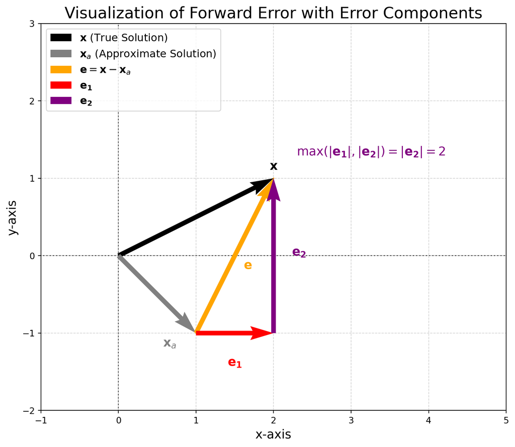

```python
import matplotlib.pyplot as plt
import numpy as np

x_true = np.array([2, 1])
x_a = np.array([1, -1])
e = x_true - x_a

plt.figure(figsize=(12, 8))
origin = np.zeros(2)

plt.quiver(*origin, *x_true, color='black', angles='xy', scale_units='xy', scale=1, label=r'$\mathbf{x}$ (True Solution)', width=0.01, zorder=5)
plt.quiver(*origin, *x_a, color='gray', angles='xy', scale_units='xy', scale=1, label=r'$\mathbf{x}_a$ (Approximate Solution)', width=0.01, zorder=5)
plt.quiver(*x_a, *e, color='orange', angles='xy', scale_units='xy', scale=1, label=r'$\mathbf{e} = \mathbf{x} - \mathbf{x}_a$', width=0.01, zorder=5)
plt.quiver(*x_a, e[0], 0, color='red', angles='xy', scale_units='xy', scale=1, label=r'$\mathbf{e_1}$', width=0.01, zorder=5)
plt.quiver(x_a[0] + e[0], x_a[1], 0, e[1], color='purple', angles='xy', scale_units='xy', scale=1, label=r'$\mathbf{e_2}$', width=0.01, zorder=5)

plt.annotate(r'$\mathbf{x}_a$', (x_a[0], x_a[1]), textcoords="offset points", xytext=(-30, -15), ha='center', color='gray', fontsize=14, zorder=6)
plt.annotate(r'$\mathbf{x}$', (x_true[0], x_true[1]), textcoords="offset points", xytext=(0, 10), ha='center', color='black', fontsize=14, zorder=6)
plt.annotate(r'$\mathbf{e}$', (x_a[0] + e[0]/2, x_a[1] + e[1]/2), textcoords="offset points", xytext=(15, -15), ha='center', color='orange', fontsize=14, zorder=6)
plt.annotate(r'$\mathbf{e_1}$', (x_a[0] + e[0]/2, x_a[1] - 0.2), textcoords="offset points", xytext=(0, -20), ha='center', color='red', fontsize=14, zorder=6)
plt.annotate(r'$\mathbf{e_2}$', (x_a[0] + e[0] + 0.1, x_a[1] + e[1]/2), textcoords="offset points", xytext=(20, 0), ha='center', color='purple', fontsize=14, zorder=6)

plt.text(x_a[0] + e[0] + 0.3, x_a[1] + e[1] + 0.3, r'$\max(|\mathbf{e_1}|, |\mathbf{e_2}|) = |\mathbf{e_2}| = 2$', color='purple', fontsize=14, zorder=6)

plt.plot([x_a[0], x_true[0]], [x_a[1], x_true[1]], color='orange', linewidth=1.5, zorder=4)  # Keep the connecting line below vectors
plt.xlim(-1, 5)
plt.ylim(-2, 3)
plt.axhline(0, color='black', linewidth=0.8, zorder=1)
plt.axvline(0, color='black', linewidth=0.8, zorder=1)
plt.grid(color='lightgray', linestyle='--', linewidth=0.7, zorder=0)
plt.legend(loc='upper left', fontsize=12)
plt.title('Visualization of Forward Error with Error Components', fontsize=18)
plt.xlabel('x-axis', fontsize=14)
plt.ylabel('y-axis', fontsize=14)
plt.gca().set_aspect('equal', adjustable='box')
plt.show()
```

### E**xplanation of the Visualization**

- **Vector Addition**:
  - The error vector $\mathbf{e}$ is drawn starting from $\mathbf{x_a}$ and pointing towards $\mathbf{x}$, demonstrating that:

    $$e_1 = 1, \quad e_2 = 2$$
- **Infinity Norm Highlighted**:
  - The maximum absolute component of the error is $|e_2| = 2$, which is the forward error $\text{FE} = \|\mathbf{e}\|_\infty$.
  - This is highlighted in the graph with a text annotation.
- **Understanding the Forward Error**:
  - By visualizing the error components, we see that the deviation occurs in both the $x$ and $y$ components.
  - The largest error is in the $y$-component, which determines the forward error.

## **Conclusion**

- **Forward Error Significance**:
  - The forward error provides a direct measure of the accuracy of the approximate solution $\mathbf{x_a}$ in relation to the true solution $\mathbf{x}$.
- **Visualization Enhancements**:
  - By adjusting $\mathbf{x_a}$ to differ by whole numbers in both components, the visualization effectively demonstrates how errors in multiple dimensions contribute to the overall forward error.
  - Decomposing the error vector into its components and highlighting the infinity norm offers a clearer understanding of how the forward error is calculated.
- **Practical Implications**:
  - In numerical computations, minimizing the forward error is crucial for obtaining accurate solutions.